# ML Model Building and Selection

## Load in libraries —-

```r
library(janitor)
library(here)
library(GGally)
library(modelr)
library(broom)
library(pROC)
library(glmulti)
library(rpart)
library(rpart.plot)
library(ranger)
library(yardstick)
library(caret)
library(MASS)
library(Hmisc)
library(reshape2)
library(tidyverse) # load tidyverse last as some dplyr verbs masked by other packages
```

## Read in data —-

```r
shs_responses <- read_csv(here::here("clean_data/shs_responses_clean.csv"))
```

```r
glimpse(shs_responses)
```

```
Rows: 50,346
Columns: 12
$ year                                  <dbl> 2012, 2012, 2012, 2012, 2012, 2012, 2012, 2012, 2012, 2012, 2…
$ community_belonging                   <chr> "Don't know", "Don't know", "Don't know", "Don't know", "Don'…
$ neighbourhood_rating                  <chr> "Fairly good", "Fairly good", "Fairly good", "Fairly good", "…
$ distance_to_nearest_green_space       <chr> "A 5 minute walk or less", "A 5 minute walk or less", "A 5 mi…
$ satisfaction_with_nearest_green_space <chr> "Fairly dissatisfied", "Fairly satisfied", "Fairly satisfied"…
$ age                                   <chr> "35 - 64 Years", "16 - 34 Years", "16 - 34 Years", "16 - 34 Y…
$ gender                                <chr> "Female", "Female", "Female", "Female", "Male", "Male", "Male…
$ economic_status                       <chr> "Full Time Employment", "Full Time Employment", "Full Time Em…
$ household_size                        <dbl> 3, 1, 2, 2, 2, 1, 2, 1, 1, 1, 1, 6, 1, 1, 1, 1, 1, 1, 2, 1, 1…
$ highest_education_level               <chr> "Degree, Professional qualification (Above SVQ Level 4)", "De…
$ nearest_green_space_use               <chr> "Once a month", "Once a week", "Once a week", "Several times …
$ volunteering_last_twelve_months       <chr> "No", "No", "No", "No", "No", "No", "No", "No", "No", "No", "…
```

```r
shs_responses <- shs_responses %>%
  mutate(across(where(is_character), as_factor))


skimr::skim(shs_responses)
```

```
── Data Summary ────────────────────────
                           Values
Name                       shs_responses
Number of rows             50346
Number of columns          12
_______________________
Column type frequency:
  factor                   10
  numeric                  2
________________________
Group variables            None
```

|  | skim_variable | n_missing | complete_rate | ordered | n_unique | top_counts |
| --- | --- | --- | --- | --- | --- | --- |
| 1 | community_belonging | 0 | 1 | FALSE | 5 | Fai: 20078, Ver: 16525, Not: 9366, Not: 3809 |
| 2 | neighbourhood_rating | 0 | 1 | FALSE | 5 | Ver: 26078, Fai: 20353, Fai: 2680, Ver: 1046 |
| 3 | distance_to_nearest_green_space | 0 | 1 | FALSE | 6 | A 5: 29013, Wit: 11715, Wit: 5601, Wit: 2004 |
| 4 | satisfaction_with_nearest_green_space | 0 | 1 | FALSE | 6 | Fai: 17556, Ver: 14733, No : 7278, Nei: 5306 |
| 5 | age | 0 | 1 | FALSE | 3 | 35 : 25795, 16 : 13215, 65 : 11336 |
| 6 | gender | 0 | 1 | FALSE | 2 | Fem: 27200, Mal: 23146 |
| 7 | economic_status | 0 | 1 | FALSE | 6 | Ful: 16512, Ret: 12349, Oth: 8646, Par: 6255 |
| 8 | highest_education_level | 0 | 1 | FALSE | 5 | Deg: 14218, Sta: 12928, Hig: 9631, HNC: 7340 |
| 9 | nearest_green_space_use | 0 | 1 | FALSE | 8 | Not: 15370, Eve: 7409, Sev: 7388, Les: 6168 |
| 10 | volunteering_last_twelve_months | 0 | 1 | FALSE | 2 | No: 35884, Yes: 14462 |

|  | skim_variable | n_missing | complete_rate | mean | sd | p0 | p25 | p50 | p75 | p100 | hist |
| --- | --- | --- | --- | --- | --- | --- | --- | --- | --- | --- | --- |
| 1 | year | 0 | 1 | 2015.306161 | 2.255358 | 2012 | 2013 | 2015 | 2017 | 2019 | ▇▅▇▂▆ |
| 2 | household_size | 0 | 1 | 2.228022 | 1.215750 | 1 | 1 | 2 | 3 | 10 | ▇▃▁▁▁ |

```r
class(shs_responses$neighbourhood_rating)
```

```
[1] "factor"
```

# Binary logisitic regression —-

```r
# Recode neighbourhood_rating so responses are divided whether "good" or "poor"
# New variable with logical binary whether rating was classed as "good"

shs_responses_binary <- shs_responses %>%
  filter(neighbourhood_rating != "No opinion") %>%
  mutate(rating_good = if_else(neighbourhood_rating %in% c("Very good", "Fairly good"), TRUE, FALSE))
```

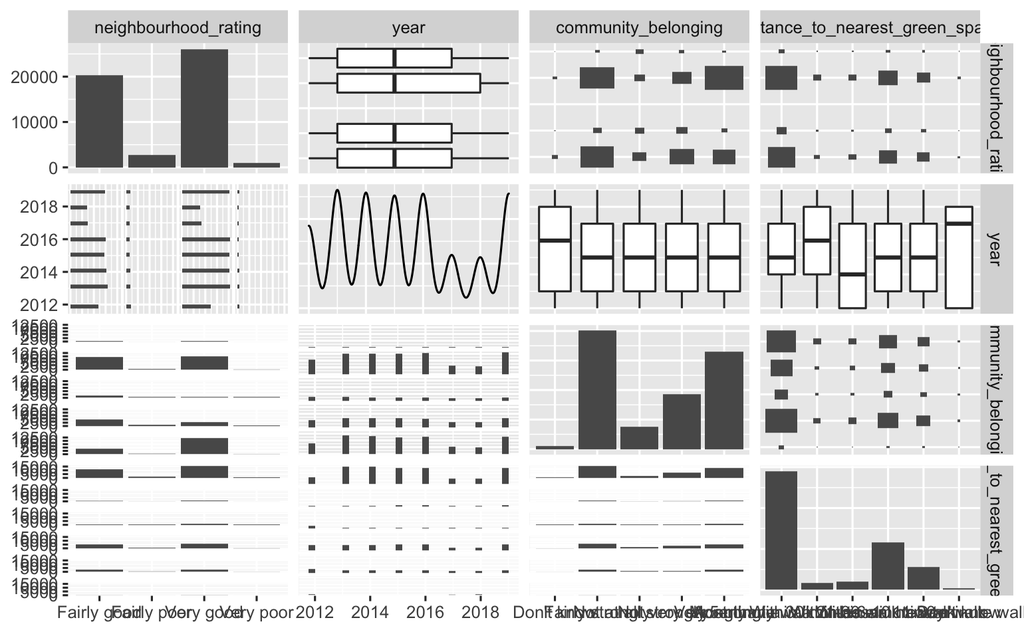

```r
# Check correlations
# Split the data into 3 parts so ggpairs runs faster
split1 <- shs_responses_binary %>%
  select(neighbourhood_rating,
         year,
         community_belonging,
         distance_to_nearest_green_space)

split2 <- shs_responses_binary %>%
  select(neighbourhood_rating,
         age,
         gender,
         economic_status,
         household_size,
         highest_education_level)

split3 <- shs_responses_binary %>%
  select(neighbourhood_rating,
         satisfaction_with_nearest_green_space,
         nearest_green_space_use,
         volunteering_last_twelve_months)

ggpairs(split1)
```

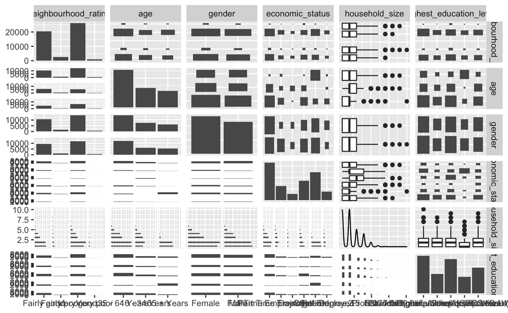

```r
ggpairs(split2)
```

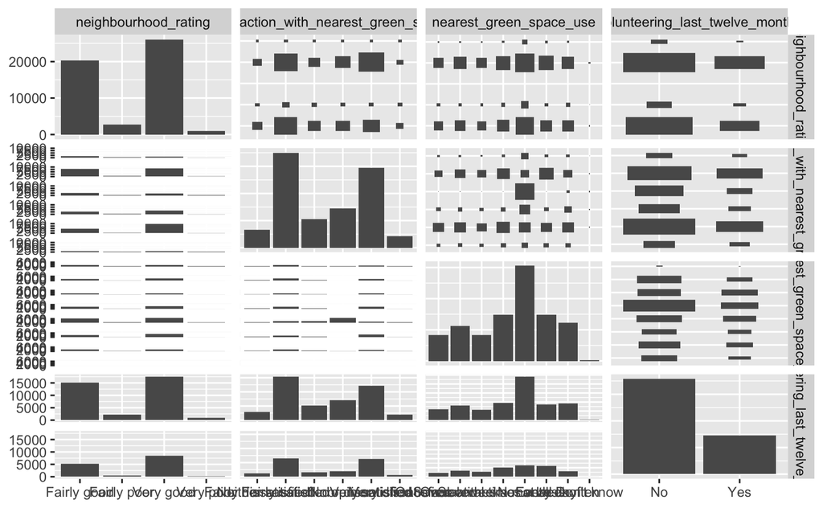

```r
ggpairs(split3)
```

Difficult to evaluate these correlations as most variables categorical

```r
# Test/train/validate split

test <- slice_sample(shs_responses_binary, prop = 0.2)
validate <- slice_sample(shs_responses_binary, prop = 0.2)
train <- slice_sample(shs_responses_binary, prop = 0.6)
```

## 1 Predictor Model

```r
# Perform logistic regression on neighbourhood_rating by single categorical predictor
# distance_to_nearest_greenspace

rating_nearest_logreg_model <- glm(rating_good ~ distance_to_nearest_green_space,
                                   data = train,
                                   family = binomial(link = "logit"))


tidy_model <- clean_names(tidy(rating_nearest_logreg_model))
tidy_model
```

| term | estimate | std_error | statistic | p_value |
| --- | --- | --- | --- | --- |
| (Intercept) | 2.5950070 | 0.02986333 | 86.896111 | 0.000000000 |
| distance_to_nearest_green_spaceMore than a 30 minute walk away | -0.1407743 | 0.12027436 | -1.170443 | 0.241822656 |
| distance_to_nearest_green_spaceWithin a 21-30 minute walk | -0.1272720 | 0.11205388 | -1.135811 | 0.256035859 |
| distance_to_nearest_green_spaceWithin a 6-10 minute walk | -0.1090085 | 0.05404035 | -2.017169 | 0.043677903 |
| distance_to_nearest_green_spaceWithin an 11-20 minute walk | -0.2149465 | 0.06844981 | -3.140207 | 0.001688287 |
| distance_to_nearest_green_spaceDon't know | -0.5269941 | 0.22823998 | -2.308947 | 0.020946503 |

```r
summary(rating_nearest_logreg_model)
```

```
Call:
glm(formula = rating_good ~ distance_to_nearest_green_space,
    family = binomial(link = "logit"), data = train)

Deviance Residuals:
    Min       1Q   Median       3Q      Max
-2.3095   0.3795   0.3795   0.3999   0.4880

Coefficients:
                                                               Estimate Std. Error z value Pr(>|z|)
(Intercept)                                                     2.59501    0.02986  86.896  < 2e-16 ***
distance_to_nearest_green_spaceMore than a 30 minute walk away -0.14077    0.12027  -1.170  0.24182
distance_to_nearest_green_spaceWithin a 21-30 minute walk      -0.12727    0.11205  -1.136  0.25604
distance_to_nearest_green_spaceWithin a 6-10 minute walk       -0.10901    0.05404  -2.017  0.04368 *
distance_to_nearest_green_spaceWithin an 11-20 minute walk     -0.21495    0.06845  -3.140  0.00169 **
distance_to_nearest_green_spaceDon't know                      -0.52699    0.22824  -2.309  0.02095 *
---
Signif. codes:  0 ‘***’ 0.001 ‘**’ 0.01 ‘*’ 0.05 ‘.’ 0.1 ‘ ’ 1

(Dispersion parameter for binomial family taken to be 1)

    Null deviance: 15856  on 30093  degrees of freedom
Residual deviance: 15841  on 30088  degrees of freedom
AIC: 15853

Number of Fisher Scoring iterations: 5
```

```r
# Test model on test set
predictions_test <- test %>%
  add_predictions(rating_nearest_logreg_model, type = "response") %>%
  select(rating_good, pred)

predictions_test
```

| rating_good | pred |
| --- | --- |
| TRUE | 0.9152941 |
| TRUE | 0.9305395 |
| TRUE | 0.9305395 |
| TRUE | 0.9305395 |
| TRUE | 0.9152941 |
| TRUE | 0.9152941 |
| TRUE | 0.9305395 |
| TRUE | 0.9305395 |
| TRUE | 0.9305395 |
| TRUE | 0.9305395 |

[output cut: 990 more lines]

```r
shs_responses_binary %>%
  count(rating_good)
```

| rating_good | n |
| --- | --- |
| FALSE | 3726 |
| TRUE | 46431 |

[output not shown]

[output cut: 990 more lines]

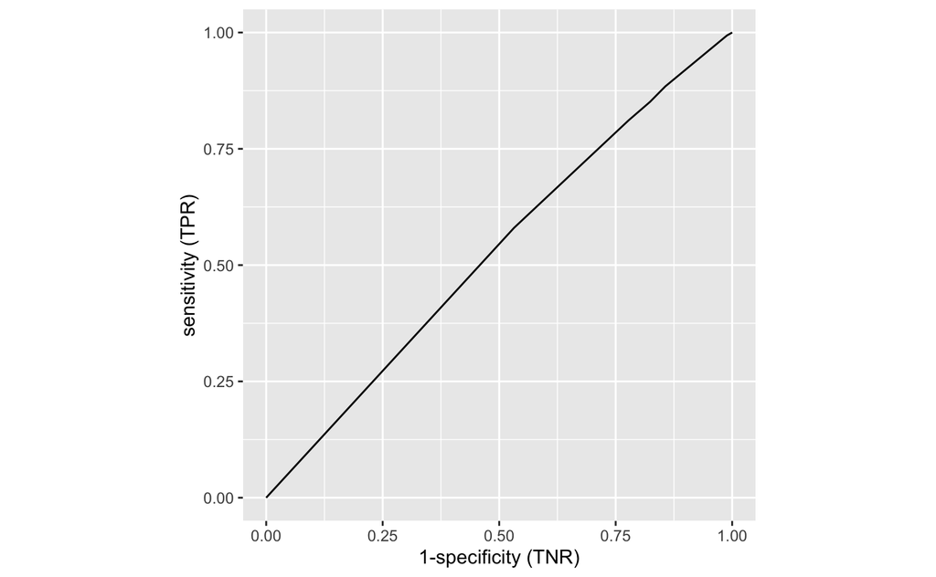

```r
# AUC

roc_obj_1pred <- rating_1pred %>%
  roc(response = rating_good, predictor = pred)
roc_curve <- ggroc(data = roc_obj_1pred, legacy.axes = TRUE) +
  coord_fixed() +
  ylab("sensitivity (TPR)") +
  xlab("1-specificity (TNR)")

roc_curve
```

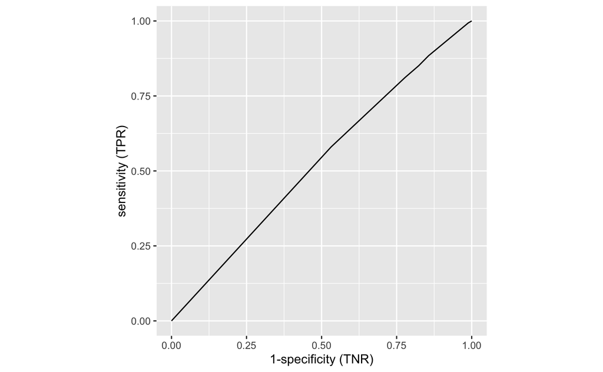

```r
classifier <- tibble(
  threshold = roc_obj_1pred$thresholds,
  sensitivity = roc_obj_1pred$sensitivities,
  specificity = roc_obj_1pred$specificities
)

roc_curve
```

```r
head(classifier)
```

| threshold | sensitivity | specificity |
| --- | --- | --- |
| -Inf | 1.0000000 | 0.00000000 |
| 0.9015246 | 0.9936249 | 0.01127214 |
| 0.9180823 | 0.8841291 | 0.14358561 |
| 0.9213596 | 0.8509401 | 0.17632850 |
| 0.9225016 | 0.8115052 | 0.22195384 |
| 0.9268470 | 0.5799143 | 0.46833065 |

- Doesn’t look like a great model
- ROC curve is only slightly better than chance

## Multi-predictor Model

```r
# Build a multi-predictor (without interactions) model
# forward model production

model_2pred <- glm(rating_good ~ distance_to_nearest_green_space + community_belonging,
                   data = train,
                   family = binomial(link = "logit"))


tidy_model_2pred<- clean_names(tidy(model_2pred))
tidy_model_2pred
```

| term | estimate | std_error | statistic | p_value |
| --- | --- | --- | --- | --- |
| (Intercept) | 2.88236074 | 0.25053249 | 11.5049381 | 1.245787e-30 |
| distance_to_nearest_green_spaceMore than a 30 minute walk away | -0.23198908 | 0.12797330 | -1.8127927 | 6.986380e-02 |
| distance_to_nearest_green_spaceWithin a 21-30 minute walk | -0.12716270 | 0.11841410 | -1.0738814 | 2.828758e-01 |
| distance_to_nearest_green_spaceWithin a 6-10 minute walk | -0.06484539 | 0.05695625 | -1.1385123 | 2.549066e-01 |
| distance_to_nearest_green_spaceWithin an 11-20 minute walk | -0.15458109 | 0.07240620 | -2.1349150 | 3.276795e-02 |
| distance_to_nearest_green_spaceDon't know | -0.11808299 | 0.24746674 | -0.4771671 | 6.332431e-01 |
| community_belongingFairly strongly | 0.32750041 | 0.25387118 | 1.2900259 | 1.970416e-01 |
| community_belongingNot at all strongly | -2.13429363 | 0.25357812 | -8.4167106 | 3.872025e-17 |
| community_belongingNot very strongly | -0.92896950 | 0.25280798 | -3.6746051 | 2.382176e-04 |
| community_belongingVery strongly | 0.82917298 | 0.25774787 | 3.2169925 | 1.295420e-03 |

```r
summary(model_2pred)
```

```
Call:
glm(formula = rating_good ~ distance_to_nearest_green_space +
    community_belonging, family = binomial(link = "logit"), data = train)

Deviance Residuals:
    Min       1Q   Median       3Q      Max
-2.7334   0.2198   0.2813   0.3034   0.9675

Coefficients:
                                                               Estimate Std. Error z value Pr(>|z|)
(Intercept)                                                     2.88236    0.25053  11.505  < 2e-16 ***
distance_to_nearest_green_spaceMore than a 30 minute walk away -0.23199    0.12797  -1.813 0.069864 .
distance_to_nearest_green_spaceWithin a 21-30 minute walk      -0.12716    0.11841  -1.074 0.282876
distance_to_nearest_green_spaceWithin a 6-10 minute walk       -0.06485    0.05696  -1.139 0.254907
distance_to_nearest_green_spaceWithin an 11-20 minute walk     -0.15458    0.07241  -2.135 0.032768 *
distance_to_nearest_green_spaceDon't know                      -0.11808    0.24747  -0.477 0.633243
community_belongingFairly strongly                              0.32750    0.25387   1.290 0.197042
community_belongingNot at all strongly                         -2.13429    0.25358  -8.417  < 2e-16 ***
community_belongingNot very strongly                           -0.92897    0.25281  -3.675 0.000238 ***
community_belongingVery strongly                                0.82917    0.25775   3.217 0.001295 **
---
Signif. codes:  0 ‘***’ 0.001 ‘**’ 0.01 ‘*’ 0.05 ‘.’ 0.1 ‘ ’ 1

(Dispersion parameter for binomial family taken to be 1)

    Null deviance: 15856  on 30093  degrees of freedom
Residual deviance: 13683  on 30084  degrees of freedom
AIC: 13703

Number of Fisher Scoring iterations: 6
```

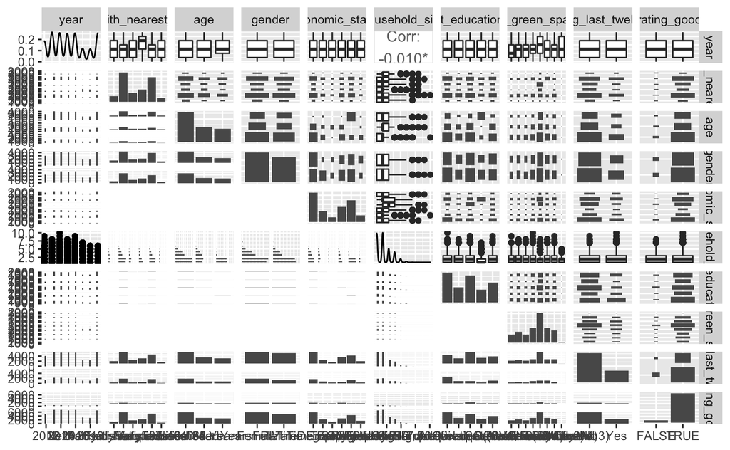

```r
# Check correlations again
shs_responses_binary %>%
  select(-c(distance_to_nearest_green_space, community_belonging, neighbourhood_rating)) %>%
  ggpairs()
```

`satisfaction_with_neares_green_space` seems like it could be a good possible candidate

```r
# Model with 3 predictors
model_3pred <- glm(rating_good ~ distance_to_nearest_green_space +
                     community_belonging + satisfaction_with_nearest_green_space,
                   data = train,
                   family = binomial(link = "logit"))


tidy_model_3pred<- clean_names(tidy(model_3pred))
tidy_model_3pred
```

| term | estimate | std_error | statistic | p_value |
| --- | --- | --- | --- | --- |
| (Intercept) | 2.10033306 | 0.26287047 | 7.989992 | 1.349471e-15 |
| distance_to_nearest_green_spaceMore than a 30 minute walk away | -0.30174640 | 0.13247722 | -2.277723 | 2.274309e-02 |
| distance_to_nearest_green_spaceWithin a 21-30 minute walk | -0.16998312 | 0.12170557 | -1.396675 | 1.625113e-01 |
| distance_to_nearest_green_spaceWithin a 6-10 minute walk | -0.09099128 | 0.05883196 | -1.546630 | 1.219525e-01 |
| distance_to_nearest_green_spaceWithin an 11-20 minute walk | -0.21998733 | 0.07486751 | -2.938355 | 3.299589e-03 |
| distance_to_nearest_green_spaceDon't know | -0.29525565 | 0.25325754 | -1.165832 | 2.436825e-01 |
| community_belongingFairly strongly | 0.39837228 | 0.25745385 | 1.547354 | 1.217779e-01 |
| community_belongingNot at all strongly | -2.09088272 | 0.25713492 | -8.131462 | 4.241452e-16 |
| community_belongingNot very strongly | -0.85129512 | 0.25637753 | -3.320475 | 8.986448e-04 |
| community_belongingVery strongly | 0.86913891 | 0.26137385 | 3.325271 | 8.833262e-04 |

[output cut: 5 more lines]

```r
summary(model_3pred)
```

```
Call:
glm(formula = rating_good ~ distance_to_nearest_green_space +
    community_belonging + satisfaction_with_nearest_green_space,
    family = binomial(link = "logit"), data = train)

Deviance Residuals:
    Min       1Q   Median       3Q      Max
-3.0288   0.1808   0.2634   0.3495   1.6579

Coefficients:
                                                                        Estimate Std. Error z value Pr(>|z|)
(Intercept)                                                              2.10033    0.26287   7.990 1.35e-15
distance_to_nearest_green_spaceMore than a 30 minute walk away          -0.30175    0.13248  -2.278 0.022743
distance_to_nearest_green_spaceWithin a 21-30 minute walk               -0.16998    0.12171  -1.397 0.162511
distance_to_nearest_green_spaceWithin a 6-10 minute walk                -0.09099    0.05883  -1.547 0.121953
distance_to_nearest_green_spaceWithin an 11-20 minute walk              -0.21999    0.07487  -2.938 0.003300
distance_to_nearest_green_spaceDon't know                               -0.29526    0.25326  -1.166 0.243683
community_belongingFairly strongly                                       0.39837    0.25745   1.547 0.121778
community_belongingNot at all strongly                                  -2.09088    0.25713  -8.131 4.24e-16
community_belongingNot very strongly                                    -0.85130    0.25638  -3.320 0.000899
community_belongingVery strongly                                         0.86914    0.26137   3.325 0.000883
satisfaction_with_nearest_green_spaceFairly satisfied                    0.84497    0.08252  10.239  < 2e-16
satisfaction_with_nearest_green_spaceNeither satisfied nor dissatisfied  0.30668    0.09329   3.288 0.001011
satisfaction_with_nearest_green_spaceNo opinion                          0.98775    0.09595  10.295  < 2e-16
satisfaction_with_nearest_green_spaceVery satisfied                      1.60703    0.09604  16.732  < 2e-16
satisfaction_with_nearest_green_spaceVery dissatisfied                  -0.79022    0.10125  -7.805 5.97e-15

(Intercept)                                                             ***
distance_to_nearest_green_spaceMore than a 30 minute walk away          *
distance_to_nearest_green_spaceWithin a 21-30 minute walk
distance_to_nearest_green_spaceWithin a 6-10 minute walk
distance_to_nearest_green_spaceWithin an 11-20 minute walk              **
distance_to_nearest_green_spaceDon't know
community_belongingFairly strongly
community_belongingNot at all strongly                                  ***
community_belongingNot very strongly                                    ***
community_belongingVery strongly                                        ***
satisfaction_with_nearest_green_spaceFairly satisfied                   ***
satisfaction_with_nearest_green_spaceNeither satisfied nor dissatisfied **
satisfaction_with_nearest_green_spaceNo opinion                         ***
satisfaction_with_nearest_green_spaceVery satisfied                     ***
satisfaction_with_nearest_green_spaceVery dissatisfied                  ***
---
Signif. codes:  0 ‘***’ 0.001 ‘**’ 0.01 ‘*’ 0.05 ‘.’ 0.1 ‘ ’ 1

(Dispersion parameter for binomial family taken to be 1)

    Null deviance: 15856  on 30093  degrees of freedom
Residual deviance: 12914  on 30079  degrees of freedom
AIC: 12944

Number of Fisher Scoring iterations: 6
```

Predictors still look fairly significant

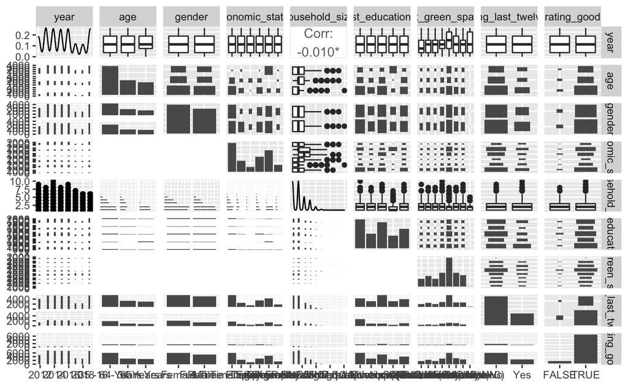

```r
# Check correlations again
shs_responses_binary %>%
  select(-c(distance_to_nearest_green_space,
            community_belonging,
            neighbourhood_rating,
            satisfaction_with_nearest_green_space)) %>%
  ggpairs()
```

`nearest_green_space_use` could also be interesting to look at

```r
# Try out a model with 4 predictors
model_4pred <- glm(rating_good ~ distance_to_nearest_green_space +
                     community_belonging +
                     satisfaction_with_nearest_green_space +
                     nearest_green_space_use,
                   data = train,
                   family = binomial(link = "logit"))


tidy_model_4pred<- clean_names(tidy(model_4pred))
tidy_model_4pred
```

| term | estimate | std_error | statistic | p_value |
| --- | --- | --- | --- | --- |
| (Intercept) | 1.96316459 | 0.27482402 | 7.1433515 | 9.108228e-13 |
| distance_to_nearest_green_spaceMore than a 30 minute walk away | -0.25813299 | 0.13379666 | -1.9292933 | 5.369446e-02 |
| distance_to_nearest_green_spaceWithin a 21-30 minute walk | -0.12991283 | 0.12334307 | -1.0532641 | 2.922199e-01 |
| distance_to_nearest_green_spaceWithin a 6-10 minute walk | -0.08801398 | 0.06002392 | -1.4663149 | 1.425625e-01 |
| distance_to_nearest_green_spaceWithin an 11-20 minute walk | -0.19622876 | 0.07643075 | -2.5674059 | 1.024626e-02 |
| distance_to_nearest_green_spaceDon't know | -0.28093700 | 0.25371487 | -1.1072942 | 2.681668e-01 |
| community_belongingFairly strongly | 0.38925587 | 0.25758953 | 1.5111479 | 1.307508e-01 |
| community_belongingNot at all strongly | -2.08723078 | 0.25726679 | -8.1130984 | 4.934507e-16 |
| community_belongingNot very strongly | -0.85244634 | 0.25651315 | -3.3232071 | 8.898881e-04 |
| community_belongingVery strongly | 0.87189248 | 0.26150014 | 3.3341951 | 8.554663e-04 |

[output cut: 12 more lines]

```r
summary(model_4pred)
```

```
Call:
glm(formula = rating_good ~ distance_to_nearest_green_space +
    community_belonging + satisfaction_with_nearest_green_space +
    nearest_green_space_use, family = binomial(link = "logit"),
    data = train)

Deviance Residuals:
    Min       1Q   Median       3Q      Max
-3.1002   0.1851   0.2524   0.3572   1.6555

Coefficients:
                                                                        Estimate Std. Error z value Pr(>|z|)
(Intercept)                                                              1.96316    0.27482   7.143 9.11e-13
distance_to_nearest_green_spaceMore than a 30 minute walk away          -0.25813    0.13380  -1.929 0.053694
distance_to_nearest_green_spaceWithin a 21-30 minute walk               -0.12991    0.12334  -1.053 0.292220
distance_to_nearest_green_spaceWithin a 6-10 minute walk                -0.08801    0.06002  -1.466 0.142563
distance_to_nearest_green_spaceWithin an 11-20 minute walk              -0.19623    0.07643  -2.567 0.010246
distance_to_nearest_green_spaceDon't know                               -0.28094    0.25371  -1.107 0.268167
community_belongingFairly strongly                                       0.38926    0.25759   1.511 0.130751
community_belongingNot at all strongly                                  -2.08723    0.25727  -8.113 4.93e-16
community_belongingNot very strongly                                    -0.85245    0.25651  -3.323 0.000890
community_belongingVery strongly                                         0.87189    0.26150   3.334 0.000855
satisfaction_with_nearest_green_spaceFairly satisfied                    0.82957    0.08275  10.025  < 2e-16
satisfaction_with_nearest_green_spaceNeither satisfied nor dissatisfied  0.36305    0.09473   3.832 0.000127
satisfaction_with_nearest_green_spaceNo opinion                          1.16444    0.10542  11.046  < 2e-16
satisfaction_with_nearest_green_spaceVery satisfied                      1.56902    0.09695  16.184  < 2e-16
satisfaction_with_nearest_green_spaceVery dissatisfied                  -0.69788    0.10401  -6.710 1.95e-11
nearest_green_space_useOnce a week                                       0.26552    0.11306   2.349 0.018848
nearest_green_space_useSeveral times a month                             0.39344    0.12534   3.139 0.001695
nearest_green_space_useSeveral times a week                              0.24863    0.10765   2.310 0.020912
nearest_green_space_useNot at all                                       -0.05910    0.09638  -0.613 0.539773
nearest_green_space_useEvery day                                         0.12815    0.10974   1.168 0.242905
nearest_green_space_useLess often                                        0.16161    0.10460   1.545 0.122334
nearest_green_space_useDon't know                                        0.31890    0.61892   0.515 0.606376

(Intercept)                                                             ***
distance_to_nearest_green_spaceMore than a 30 minute walk away          .
distance_to_nearest_green_spaceWithin a 21-30 minute walk
distance_to_nearest_green_spaceWithin a 6-10 minute walk
distance_to_nearest_green_spaceWithin an 11-20 minute walk              *
```

[output cut: 12 more lines]

```
nearest_green_space_useSeveral times a week                             *
nearest_green_space_useNot at all
nearest_green_space_useEvery day
nearest_green_space_useLess often
nearest_green_space_useDon't know
---
Signif. codes:  0 ‘***’ 0.001 ‘**’ 0.01 ‘*’ 0.05 ‘.’ 0.1 ‘ ’ 1

(Dispersion parameter for binomial family taken to be 1)

    Null deviance: 15856  on 30093  degrees of freedom
Residual deviance: 12885  on 30072  degrees of freedom
AIC: 12929

Number of Fisher Scoring iterations: 6
```

- predictors are still mostly significant, aic score not much lower

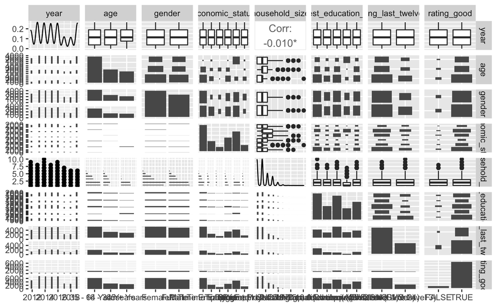

```r
# Check correlations again
shs_responses_binary %>%
  select(-c(distance_to_nearest_green_space,
            community_belonging,
            neighbourhood_rating,
            satisfaction_with_nearest_green_space,
            nearest_green_space_use)) %>%
  ggpairs()
```

- `economic_status` maybe?

```r
# One last logistic model with 5 predictors
model_5pred <- glm(rating_good ~ distance_to_nearest_green_space +
                     community_belonging +
                     satisfaction_with_nearest_green_space +
                     nearest_green_space_use +
                     economic_status,
                   data = train,
                   family = binomial(link = "logit"))


tidy_model_5pred<- clean_names(tidy(model_5pred))


summary(model_5pred)
```

```
Call:
glm(formula = rating_good ~ distance_to_nearest_green_space +
    community_belonging + satisfaction_with_nearest_green_space +
    nearest_green_space_use + economic_status, family = binomial(link = "logit"),
    data = train)

Deviance Residuals:
    Min       1Q   Median       3Q      Max
-3.1435   0.1765   0.2437   0.3589   1.8430

Coefficients:
                                                                        Estimate Std. Error z value Pr(>|z|)
(Intercept)                                                              2.11434    0.27805   7.604 2.87e-14
distance_to_nearest_green_spaceMore than a 30 minute walk away          -0.29227    0.13482  -2.168 0.030174
distance_to_nearest_green_spaceWithin a 21-30 minute walk               -0.11350    0.12373  -0.917 0.358993
distance_to_nearest_green_spaceWithin a 6-10 minute walk                -0.07009    0.06062  -1.156 0.247565
distance_to_nearest_green_spaceWithin an 11-20 minute walk              -0.16848    0.07716  -2.184 0.028997
distance_to_nearest_green_spaceDon't know                               -0.32337    0.25380  -1.274 0.202618
community_belongingFairly strongly                                       0.38046    0.25857   1.471 0.141184
community_belongingNot at all strongly                                  -2.05454    0.25825  -7.956 1.78e-15
community_belongingNot very strongly                                    -0.85701    0.25749  -3.328 0.000874
community_belongingVery strongly                                         0.86010    0.26257   3.276 0.001054
satisfaction_with_nearest_green_spaceFairly satisfied                    0.82198    0.08347   9.848  < 2e-16
satisfaction_with_nearest_green_spaceNeither satisfied nor dissatisfied  0.36603    0.09561   3.828 0.000129
satisfaction_with_nearest_green_spaceNo opinion                          1.15023    0.10621  10.830  < 2e-16
satisfaction_with_nearest_green_spaceVery satisfied                      1.54283    0.09771  15.789  < 2e-16
satisfaction_with_nearest_green_spaceVery dissatisfied                  -0.64083    0.10508  -6.098 1.07e-09
nearest_green_space_useOnce a week                                       0.29632    0.11394   2.601 0.009307
nearest_green_space_useSeveral times a month                             0.40572    0.12632   3.212 0.001319
nearest_green_space_useSeveral times a week                              0.30618    0.10869   2.817 0.004847
nearest_green_space_useNot at all                                       -0.02013    0.09748  -0.207 0.836379
nearest_green_space_useEvery day                                         0.16968    0.11055   1.535 0.124820
nearest_green_space_useLess often                                        0.17038    0.10527   1.619 0.105545
nearest_green_space_useDon't know                                        0.39957    0.62640   0.638 0.523544
economic_statusPart Time Employment                                      0.01488    0.08675   0.172 0.863810
economic_statusTraining                                                  0.01218    0.11183   0.109 0.913250
economic_statusOther                                                    -0.78164    0.06279 -12.449  < 2e-16
economic_statusRetired                                                  -0.05285    0.07083  -0.746 0.455562
economic_statusSelf Employed                                             0.12006    0.11225   1.070 0.284825

```

[output cut: 22 more lines]

```
economic_statusPart Time Employment
economic_statusTraining
economic_statusOther                                                    ***
economic_statusRetired
economic_statusSelf Employed
---
Signif. codes:  0 ‘***’ 0.001 ‘**’ 0.01 ‘*’ 0.05 ‘.’ 0.1 ‘ ’ 1

(Dispersion parameter for binomial family taken to be 1)

    Null deviance: 15856  on 30093  degrees of freedom
Residual deviance: 12682  on 30067  degrees of freedom
AIC: 12736

Number of Fisher Scoring iterations: 6
```

AIC is down but at what cost? Drop in AIC after 3 predictors is quite a bit lower than from 2 to 3 predictors

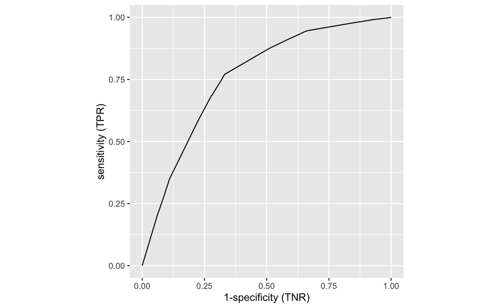

```r
# AUC for 2 predictor model

rating_2pred <- shs_responses_binary %>%
  add_predictions(model_2pred, type = "response")

roc_obj_2pred <- rating_2pred %>%
  roc(response = rating_good, predictor = pred)
roc_curve_2pred <- ggroc(data = roc_obj_2pred, legacy.axes = TRUE) +
  coord_fixed() +
  ylab("sensitivity (TPR)") +
  xlab("1-specificity (TNR)")


classifier_2pred <- tibble(
  threshold = roc_obj_2pred$thresholds,
  sensitivity = roc_obj_2pred$sensitivities,
  specificity = roc_obj_2pred$specificities
)

roc_curve_2pred
```

```r
head(classifier_2pred)
```

| threshold | sensitivity | specificity |
| --- | --- | --- |
| -Inf | 1.0000000 | 0.00000000 |
| 0.6351974 | 0.9984062 | 0.01019860 |
| 0.6472944 | 0.9925265 | 0.05823940 |
| 0.6514550 | 0.9905451 | 0.07461084 |
| 0.6584716 | 0.9894682 | 0.07944176 |
| 0.6716074 | 0.9763735 | 0.16156736 |

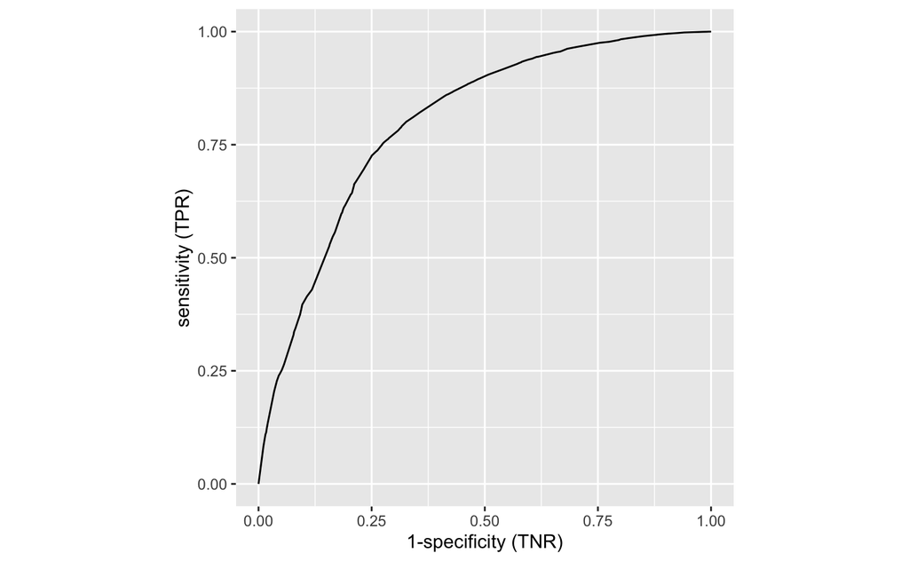

```r
# AUC for 3 predictor model

rating_3pred <- shs_responses_binary %>%
  add_predictions(model_3pred, type = "response")

roc_obj_3pred <- rating_3pred %>%
  roc(response = rating_good, predictor = pred)
roc_curve_3pred <- ggroc(data = roc_obj_3pred, legacy.axes = TRUE) +
  coord_fixed() +
  ylab("sensitivity (TPR)") +
  xlab("1-specificity (TNR)")


classifier_3pred <- tibble(
  threshold = roc_obj_3pred$thresholds,
  sensitivity = roc_obj_3pred$sensitivities,
  specificity = roc_obj_3pred$specificities
)

roc_curve_3pred
```

```r
head(classifier_3pred)
```

| threshold | sensitivity | specificity |
| --- | --- | --- |
| -Inf | 1.0000000 | 0.000000000 |
| 0.2536442 | 0.9999354 | 0.001878690 |
| 0.2615254 | 0.9999354 | 0.002147075 |
| 0.2737627 | 0.9998492 | 0.006977992 |
| 0.2868103 | 0.9997200 | 0.008319914 |
| 0.3045206 | 0.9994831 | 0.019323671 |

```r
NA
```

[output not shown]

A lot better than the 1 predictor model. Hard to see whether it’s any better than 2 predictor model.

```r
roc_curve_comparison <- ggroc(data = list(pred3 = roc_obj_3pred, pred2 = roc_obj_2pred), legacy.axes = TRUE) +
  coord_fixed()


auc(roc_obj_2pred, )
```

```
Area under the curve: 0.7606
```

```r
auc(roc_obj_3pred, )
```

```
Area under the curve: 0.7993
```

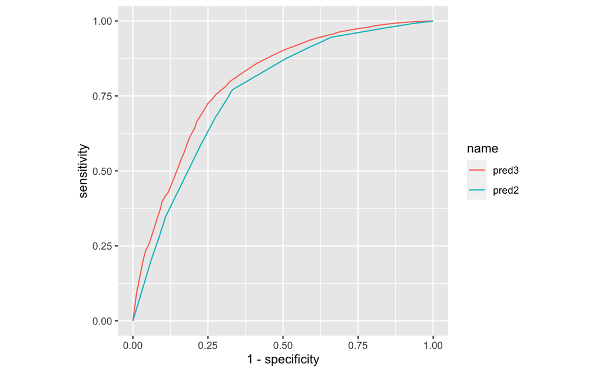

```r
roc_curve_comparison
```

3 predictors are better than 2.

*test and validate*

# Decision tree model —-

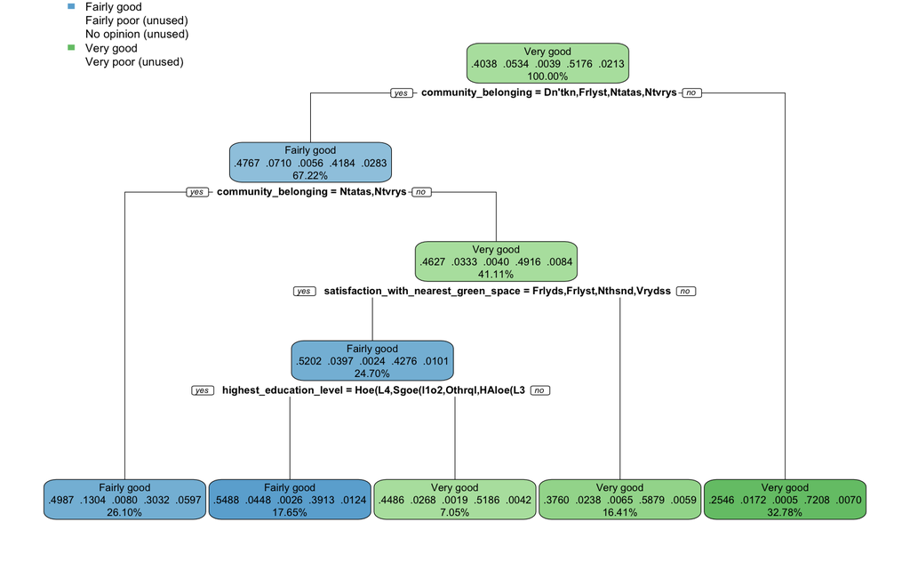

```r
test_2 <- slice_sample(shs_responses, prop = 0.2)
validate_2 <- slice_sample(shs_responses, prop = 0.2)
train_2 <- slice_sample(shs_responses, prop = 0.6)


shs_tree <- rpart(
  formula = neighbourhood_rating ~.,
  data = train_2,
  method = "class"
)

rpart.plot(shs_tree,
           yesno = 2,
           fallen.leaves = TRUE,
           faclen = 6,
           digits = 4)
```

```r
tree_test_pred <- test_2 %>%
  add_predictions(shs_tree, type = "class")
```

[output not shown]

```r
accuracy

sensitivity
```

| .metric | .estimator | .estimate |
| --- | --- | --- |
| sens | macro | 0.3379187 |

```r
specificity
```

| .metric | .estimator | .estimate |
| --- | --- | --- |
| spec | macro | 0.88348 |

# Random Forest Classifier —-

```r
# Random forest

rf_classifier <- ranger(neighbourhood_rating ~.,
                        data = train_2,
                        importance = "impurity",
                        num.trees = 1000,
                        mtry = 2,
                        min.node.size = 5)

rf_classifier
```

```
Ranger result

Call:
 ranger(neighbourhood_rating ~ ., data = train_2, importance = "impurity",      num.trees = 1000, mtry = 2, min.node.size = 5)

Type:                             Classification
Number of trees:                  1000
Sample size:                      30207
Number of independent variables:  11
Mtry:                             2
Target node size:                 5
Variable importance mode:         impurity
Splitrule:                        gini
OOB prediction error:             39.33 %
```

Prediction error of almost 40% is not the best

```r
importance(rf_classifier)
```

```
                                 year                   community_belonging
                             868.6955                             1308.2305
      distance_to_nearest_green_space satisfaction_with_nearest_green_space
                             508.5939                              850.0793
                                  age                                gender
                             317.8735                              265.5863
                      economic_status                        household_size
                             568.1915                              616.1363
              highest_education_level               nearest_green_space_use
                             555.2944                              760.2178
      volunteering_last_twelve_months
                             194.1611
```

*Most important variables* 1. `community_belonging` 2. `year` 3. `satisfaction_with_nearest_green_space`

*Least important variables* 1. `volunteering_last_twelve_months` 2. `gender` 3. `age`

```r
tree_test_pred <- test_2 %>%
  mutate(pred = predict(rf_classifier, data = test_2)$predictions)

confusionMatrix(tree_test_pred$pred, tree_test_pred$neighbourhood_rating)
```

```
Confusion Matrix and Statistics

             Reference
Prediction    Fairly good Fairly poor No opinion Very good Very poor
  Fairly good        2552         355         32       889       135
  Fairly poor           1          50          0         2         3
  No opinion            0           0          1         0         0
  Very good          1501         134         11      4345        30
  Very poor             0           6          0         0        22

Overall Statistics

               Accuracy : 0.6922
                 95% CI : (0.6831, 0.7012)
    No Information Rate : 0.52
    P-Value [Acc > NIR] : < 2.2e-16

                  Kappa : 0.4195

 Mcnemar's Test P-Value : NA

Statistics by Class:

                     Class: Fairly good Class: Fairly poor Class: No opinion Class: Very good
Sensitivity                      0.6295           0.091743         2.273e-02           0.8298
Specificity                      0.7654           0.999370         1.000e+00           0.6532
Pos Pred Value                   0.6440           0.892857         1.000e+00           0.7216
Neg Pred Value                   0.7540           0.950564         9.957e-01           0.7799
Prevalence                       0.4026           0.054127         4.370e-03           0.5200
Detection Rate                   0.2535           0.004966         9.931e-05           0.4315
Detection Prevalence             0.3936           0.005562         9.931e-05           0.5980
Balanced Accuracy                0.6975           0.545557         5.114e-01           0.7415
                     Class: Very poor
Sensitivity                  0.115789
Specificity                  0.999393
Pos Pred Value               0.785714
Neg Pred Value               0.983269
Prevalence                   0.018870
Detection Rate               0.002185
Detection Prevalence         0.002781
Balanced Accuracy            0.557591
```

### Just a test to see whether the RF imputation of NAs has a major effect on performance

```r
skimr::skim(shs_responses_raw)
```

```
── Data Summary ────────────────────────
                           Values
Name                       shs_responses_raw
Number of rows             50346
Number of columns          12
_______________________
Column type frequency:
  factor                   10
  numeric                  2
________________________
Group variables            None
```

|  | skim_variable | n_missing | complete_rate | ordered | n_unique | top_counts |
| --- | --- | --- | --- | --- | --- | --- |
| 1 | community_belonging | 0 | 1 | FALSE | 5 | Fai: 20078, Ver: 16525, Not: 9366, Not: 3809 |
| 2 | neighbourhood_rating | 0 | 1 | FALSE | 5 | Ver: 26078, Fai: 20353, Fai: 2680, Ver: 1046 |
| 3 | distance_to_nearest_green_space | 0 | 1 | FALSE | 6 | A 5: 29013, Wit: 11715, Wit: 5601, Wit: 2004 |
| 4 | satisfaction_with_nearest_green_space | 0 | 1 | FALSE | 7 | Fai: 17002, Ver: 14076, Not: 6906, Nei: 4686 |
| 5 | age | 0 | 1 | FALSE | 3 | 35 : 25795, 16 : 13215, 65 : 11336 |
| 6 | gender | 0 | 1 | FALSE | 2 | Fem: 27200, Mal: 23146 |
| 7 | economic_status | 0 | 1 | FALSE | 7 | Ful: 16512, Ret: 12349, Oth: 8645, Par: 6255 |
| 8 | highest_education_level | 0 | 1 | FALSE | 6 | Deg: 13284, Sta: 10292, Not: 8979, Hig: 8761 |
| 9 | nearest_green_space_use | 0 | 1 | FALSE | 9 | Not: 12345, Not: 9078, Sev: 6698, Eve: 6009 |
| 10 | volunteering_last_twelve_months | 0 | 1 | FALSE | 3 | No: 31794, Yes: 13113, Not: 5439 |

|  | skim_variable | n_missing | complete_rate | mean | sd | p0 | p25 | p50 | p75 | p100 | hist |
| --- | --- | --- | --- | --- | --- | --- | --- | --- | --- | --- | --- |
| 1 | year | 0 | 1 | 2015.306161 | 2.255358 | 2012 | 2013 | 2015 | 2017 | 2019 | ▇▅▇▂▆ |
| 2 | household_size | 0 | 1 | 2.228022 | 1.215750 | 1 | 1 | 2 | 3 | 10 | ▇▃▁▁▁ |

```r
importance(rf_classifier_raw)
```

```
                                 year                   community_belonging
                             651.6044                             1329.3870
      distance_to_nearest_green_space satisfaction_with_nearest_green_space
                             506.5492                              698.5104
                                  age                                gender
                             308.1079                              268.4206
                      economic_status                        household_size
                             563.0700                              614.8749
              highest_education_level               nearest_green_space_use
                             659.3266                              721.5060
      volunteering_last_twelve_months
                             239.4298
```

Imputation using a random forest doesn’t seem to have altered the data in a significant way compared to a new class imputation

```r
# Now with dropping NAs (but they are MNAR, so not the best approach)
shs_responses_non_imp <- read_csv(here::here("raw_data/shs_aggregate_responses.csv")) %>%
  clean_names() %>%
  filter(n_persons == 1) %>%
  select(-n_persons) %>%
  na.omit()
skimr::skim(shs_responses_non_imp)
```

```
── Data Summary ────────────────────────
                           Values
Name                       shs_responses_non_imp
Number of rows             31283
Number of columns          12
_______________________
Column type frequency:
  character                10
  numeric                  2
________________________
Group variables            None
```

|  | skim_variable | n_missing | complete_rate | min | max | empty | n_unique | whitespace |
| --- | --- | --- | --- | --- | --- | --- | --- | --- |
| 1 | community_belonging | 0 | 1 | 10 | 19 | 0 | 5 | 0 |
| 2 | neighbourhood_rating | 0 | 1 | 9 | 11 | 0 | 5 | 0 |
| 3 | distance_to_nearest_green_space | 0 | 1 | 23 | 31 | 0 | 5 | 0 |
| 4 | satisfaction_with_nearest_green_space | 0 | 1 | 10 | 34 | 0 | 6 | 0 |
| 5 | age | 0 | 1 | 10 | 13 | 0 | 3 | 0 |
| 6 | gender | 0 | 1 | 4 | 6 | 0 | 2 | 0 |
| 7 | economic_status | 0 | 1 | 5 | 20 | 0 | 6 | 0 |
| 8 | highest_education_level | 0 | 1 | 19 | 54 | 0 | 5 | 0 |
| 9 | nearest_green_space_use | 0 | 1 | 9 | 21 | 0 | 8 | 0 |
| 10 | volunteering_last_twelve_months | 0 | 1 | 2 | 3 | 0 | 2 | 0 |

|  | skim_variable | n_missing | complete_rate | mean | sd | p0 | p25 | p50 | p75 | p100 | hist |
| --- | --- | --- | --- | --- | --- | --- | --- | --- | --- | --- | --- |
| 1 | year | 0 | 1 | 2015.413036 | 2.070586 | 2013 | 2014 | 2015 | 2016 | 2019 | ▇▃▅▁▅ |
| 2 | household_size | 0 | 1 | 2.259726 | 1.203759 | 1 | 1 | 2 | 3 | 10 | ▇▃▁▁▁ |

```r
test_4 <- slice_sample(shs_responses_non_imp, prop = 0.2)
validate_4 <- slice_sample(shs_responses_non_imp, prop = 0.2)
train_4 <- slice_sample(shs_responses_non_imp, prop = 0.6)

rf_classifier_non_imp <- ranger(neighbourhood_rating ~.,
                        data = train_4,
                        importance = "impurity",
                        num.trees = 1000,
                        mtry = 2,
                        min.node.size = 5)

rf_classifier_non_imp
```

```
Ranger result

Call:
 ranger(neighbourhood_rating ~ ., data = train_4, importance = "impurity",      num.trees = 1000, mtry = 2, min.node.size = 5)

Type:                             Classification
Number of trees:                  1000
Sample size:                      18769
Number of independent variables:  11
Mtry:                             2
Target node size:                 5
Variable importance mode:         impurity
Splitrule:                        gini
OOB prediction error:             37.88 %
```

```r
importance(rf_classifier_non_imp)
```

```
                                 year                   community_belonging
                             441.4915                              925.9537
      distance_to_nearest_green_space satisfaction_with_nearest_green_space
                             290.5739                              522.9621
                                  age                                gender
                             216.2448                              166.4178
                      economic_status                        household_size
                             357.9665                              396.7504
              highest_education_level               nearest_green_space_use
                             383.8424                              502.8645
      volunteering_last_twelve_months
                             123.4168
```

Maybe taking out nas is worth it?

```r
confusionMatrix(tree_test_pred_non_imp$pred, tree_test_pred_non_imp$neighbourhood_rating)
```

```
Confusion Matrix and Statistics

             Reference
Prediction    Fairly good No opinion Very good Fairly poor Very poor
  Fairly good        1472         13       478         178        56
  No opinion            0          2         0           0         0
  Very good          1023         10      2922          68        17
  Fairly poor           0          0         0          13         0
  Very poor             0          0         0           0         4

Overall Statistics

               Accuracy : 0.7054
                 95% CI : (0.6939, 0.7167)
    No Information Rate : 0.5435
    P-Value [Acc > NIR] : < 2.2e-16

                  Kappa : 0.4211

 Mcnemar's Test P-Value : NA

Statistics by Class:

                     Class: Fairly good Class: No opinion Class: Very good Class: Fairly poor
Sensitivity                      0.5900         0.0800000           0.8594           0.050193
Specificity                      0.8072         1.0000000           0.6085           1.000000
Pos Pred Value                   0.6700         1.0000000           0.7233           1.000000
Neg Pred Value                   0.7480         0.9963224           0.7843           0.960596
Prevalence                       0.3988         0.0039962           0.5435           0.041400
Detection Rate                   0.2353         0.0003197           0.4671           0.002078
Detection Prevalence             0.3512         0.0003197           0.6458           0.002078
Balanced Accuracy                0.6986         0.5400000           0.7340           0.525097
                     Class: Very poor
Sensitivity                 0.0519481
Specificity                 1.0000000
Pos Pred Value              1.0000000
Neg Pred Value              0.9883237
Prevalence                  0.0123082
Detection Rate              0.0006394
Detection Prevalence        0.0006394
Balanced Accuracy           0.5259740
```

Accuracy hasn’t gone up that much. I’d prefer to stick with the model with imputed values.

# Ordinal logistic regression —-

```r
train_2$neighbourhood_rating <- ordered(train_2$neighbourhood_rating,
                                        levels = c("Very good",
                                                   "Fairly good",
                                                   "No opinion",
                                                   "Fairly poor",
                                                   "Very poor"))

test_2$neighbourhood_rating <- ordered(test_2$neighbourhood_rating,
                                       levels = c("Very good",
                                                  "Fairly good",
                                                  "No opinion",
                                                  "Fairly poor",
                                                  "Very poor"))
```

```r
# Following workflow from https://www.analyticsvidhya.com/blog/2016/02/multinomial-ordinal-logistic-regression/#h2_7 [accessed 19/09/22]
# Creat ordered model using polr()
ordered_model_1pred <- polr(neighbourhood_rating ~ distance_to_nearest_green_space,
                            data = train_2,
                            Hess = TRUE)

summary(ordered_model_1pred)
```

| Value | Std. Error | t value | p value |
| --- | --- | --- | --- |
| -0.2184205 | 0.06606339 | -3.306226 | 9.456178e-04 |
| 0.1993389 | 0.05664378 | 3.519166 | 4.329054e-04 |
| 0.1444634 | 0.02740178 | 5.272046 | 1.349111e-07 |
| 0.1990133 | 0.03633489 | 5.477196 | 4.321175e-08 |
| 0.4216741 | 0.13724189 | 3.072489 | 2.122819e-03 |
| 0.1301513 | 0.01500166 | 8.675789 | 4.106927e-18 |
| 2.5256216 | 0.02364618 | 106.808882 | 0.000000e+00 |
| 2.5808658 | 0.02410601 | 107.063148 | 0.000000e+00 |
| 3.8910121 | 0.04110659 | 94.656649 | 0.000000e+00 |

# Top 3 models —-

1. Random Forest model (with imputed values from missForest) *Pros*
- Keeps information
- Able to see most important variables
- 70% accuracy (could be more with fine-tuning of hyperparameters and validation) *Cons*
- 40% OOB error (need to research this more)
2. Logistic 3 predictor model *Pros*
- AUC of 0.79
- good sensitivity value (could be to do with the data) *Cons*
- bad specificity
- lose info on dependent variable
3. Ordinal Regression *Pros*
- Keeps info and orders dependent variable (without assumption of equal distance)
- Significant p-values
- Odds ratio for each level
- Interacts levels *Cons*
- Hard to interpret *
- I’m not familiar with it